NTUH HSINCHU · INTERNAL MEDICINE · 2023 → 2026 REV.

# 台大內科住院醫師 之 如何訂定自我進修計劃

謝慕揚 醫師  
新竹臺大分院 心臟內科 · 內科部

01

AGENDA

00 / 今天的順序

## 五個段落，一份可以帶走的計劃

01

### 自我介紹

我是誰、我怎麼走到這裡。

02

### 為什麼留在新竹

沒有想要回台北──一個關於選擇的故事。

03

### 心得分享

主治醫師執行教學工作的實務經驗。

04

### 困境分析

時間、體力、心理，三種稀缺資源。

05

### 討論

你的計劃，只有你自己寫得出來。

+

### 本次增修

每一節加上可查證的醫學教育文獻與數據。

02

AGENDA

00 / 心得分享

## 三條主線

- **心臟內科主治醫師執行教學工作的心得分享**  
  從被教的人，變成教人的人，看見的東西完全不同。
- **新竹臺大的教學活動進程回顧**  
  一個分院的教學系統是怎麼一步一步長出來的。
- **主治醫師的工作壓力與心理調適**──如何保持愉快心情  
  這一段其實是整場最重要的：能持續，才有進步。

03

01 / 第一原則

# Nobody is the same…

每個人的計劃  
都不應該相同

住院醫師的起點、家庭狀況、體力、目標科別、甚至你想在幾歲之前完成什麼， 全部都不一樣。照抄學長的計劃，是最沒有效率的做法。 但「不一樣」不等於「隨便」──不一樣的是*內容*，一樣的是*方法學*。

04

EVIDENCE

01 / 為什麼需要一份寫下來的計劃 2026 增修

## 壞消息：醫師的自我評估準確度很差

- 系統性回顧納入 **17 篇**比較「自評 vs. 客觀測量」的研究， 其中 **13 篇**顯示兩者相關性差、甚至沒有相關<sup>1</sup>。
- 更糟的是：**自認最有把握的人，落差往往最大**；表現最差的族群最容易高估自己<sup>1</sup>。
- 小兒科住院醫師的全國調查也發現：住院醫師「說出自己強項」的信心很高， 但「訂出目標並完成」的信心明顯偏低<sup>2</sup>。

13/17

研究顯示醫師自評  
與客觀表現不相關或負相關<sup>1</sup>

×2

ACGME 建議：住院醫師  
每年至少寫 2 次個人學習計劃<sup>3</sup>

結論：不要靠感覺管理自己的成長。要有**外部參照**（指導者、里程碑、客觀評量）＋**書面計劃**。

05

02

THE FRAMEWORK

## 進修計劃的骨架

先講方法學。內容你自己填，但骨架有標準答案。

06

FRAMEWORK

02 / 自我進修計劃

## 三個「Should」

SHOULD BE

### Comprehensive

全面。不是只練一項技術，而是六大核心能力都要有著落──包含你最不想面對的那一項。

SHOULD BE

### Goal-focused

有目標。目標要具體到「做完之後你會知道自己做完了」。

SHOULD BE

### Step-by-step

可分步。三年份的目標拆成季、拆成月、拆成這一輪 R 的一件事。

這三句是 2023 年那份簡報上唯一寫下來的原則。接下來的內容，都是在把它變成可執行的東西。

07

EVIDENCE

02 / 這件事有正式名字 2026 增修

## Individualized Learning Plan（ILP）／個人化學習計劃

- **它是什麼：**由學習者主導、寫成文件、可被追蹤的學習契約。在 competency-based medical education（CBME）中是標準工具。
- **證據怎麼說：**全國性調查（46 個訓練計劃、992 位住院醫師）發現── 會不會設定「可測量」的目標，是自主學習能否成功的關鍵因素<sup>2</sup>。
- **但寫得好的不多：**前瞻性研究分析內科住院醫師的輪訓學習目標， 發現大量目標**過於籠統、缺乏具體行動與評估方式**<sup>4</sup>。

ILP 應包含

白話

Self-assessment

我現在在哪裡（用外部資料佐證）

Goals

我要到哪裡（可測量）

Action plan

我要做什麼、什麼時候做

Resources

誰教我、用什麼資源

Assessment

怎麼知道我到了

Review date

什麼時候回來檢討

08

EVIDENCE

02 / 引擎 2026 增修

## 自我調節學習的三段循環<sup>5</sup>

PHASE 1

### Forethought 事前

任務分析、目標設定、策略選擇。  
**問自己：**這次 CVICU 我要拿下什麼？用什麼方法？

PHASE 2

### Performance 執行中

自我監控、專注、即時調整。  
**問自己：**我現在是在練習，還是只是在把工作做完？

PHASE 3

### Self-reflection 事後

自我評判、歸因、調整下一輪。  
**問自己：**做不好是策略問題還是能力問題？

關鍵在第三段。多數住院醫師只有 Phase 2──很忙、很認真，但沒有 Phase 1 的設計與 Phase 3 的回看， 三年下來累積的是*年資*，不是*能力*。

09

HOW-TO

02 / 動手寫 2026 增修

## 壞目標 vs. 好目標

✗ 常見寫法（無法追蹤）

✓ 改寫後（可測量、有期限、有評估）

「加強心臟超音波」

本輪 R2 CV 期間完成 30 例 basic TTE，每例自存影像，每週五請 VS 回看 3 例，月底能獨立判讀 LVEF 與 IVC。

「多讀 paper」

每週一篇與當週主治病人相關的 review，用 5 句話寫進病歷 A/P，季末累積 12 篇並整理成一份 ppt。

「改善溝通技巧」

每月挑 2 次家族會議，事前畫好一張解釋圖，事後請學長用 SPIKES 六步驟給我回饋。

「開始做研究」

6 月底前決定題目與 PI，8 月底完成 IRB 送件，12 月底完成 REDCap 收案表單與前 30 例。

檢核方式：把目標拿給同事看，如果對方問「所以你到底要做什麼」，那就是還沒寫完。

10

HOW-TO

02 / 帶走這一頁 2026 增修

## 一頁式進修計劃模板

§1 · 現況

### 我在哪裡

列 3 項客觀資料：in-training 考試成績、EPA/里程碑評分、最近一次被指出的缺點。**不准只寫感覺。**

§2 · 目標

### 這一年的 3 個目標

只准寫三個。每個都要有數字與截止日。分別對應：知識、技術、學術。

§3 · 行動

### 每個目標拆 3 步

第一步必須是「本週就能做」的動作。不能是「找時間開始」。

§4 · 資源

### 誰、什麼、多少錢

指導者姓名（要真的去問過）、教材、預算、需要的時間段。

§5 · 驗收

### 怎麼證明我做到了

影像存檔數、發表、通過的評量、能獨立完成的 EPA 層級。

§6 · 回顧

### 兩個日期

期中檢討日與期末檢討日，現在就寫進 Google Calendar，設成重複事件。

11

03

SIX COMPETENCIES

## 住院醫師六大核心能力 DRAKE'S VERSION 1.0

不是 ACGME 那六個。是我實際觀察後，覺得住院醫師真正該練的六件事。

12

DRAKE V1.0

03 / Drake's version 1.0

## 六大核心能力

01

### 聚焦式文獻查詢

Focused, web-based literature review — 以病人為單位的 case-focused learning。

02

### 團隊合作

Teamwork — 護理、藥師、營養、社工、家屬，都是團隊。

03

### 超音波＋理學檢查

Combined ultrasound skills and rational physical exam。

04

### 寫作與研究能力

Writing and research skills — 能把想法變成可被檢驗的文字。

05

### 自我保護與態度

Self-protection and personal attitude enhancement。

06

### 家屬解釋與照護規劃

Family explanation technique ＋ comprehensive evidence-based care planning。

13

MAPPING

03 / 對照 2026 增修

## 和 ACGME 六大核心能力怎麼對上<sup>3</sup>

ACGME Core Competency

Drake's version 1.0 對應項目

Medical Knowledge

① 聚焦式文獻查詢 ＋ ③ 超音波判讀知識

Patient Care & Procedural Skills

③ 超音波＋理學檢查 ＋ ⑥ 照護規劃

Practice-based Learning & Improvement

① case-focused learning ＋ ④ 研究能力

Interpersonal & Communication Skills

⑥ 家屬解釋技巧 ＋ ② 團隊合作

Professionalism

⑤ 自我保護與態度

Systems-based Practice

② 團隊合作 ＋ ⑥ evidence-based care planning

Milestones 2.0（2021 起施行）刻意採用成長心態的評分邏輯── R1 拿到 Level 1 不代表「有缺陷」，只代表「在起點」。**不要用里程碑分數互相比較，要用它來定位下一步。**<sup>3</sup>

14

04

KNOWLEDGE

## 知識：怎麼查、怎麼讀、 怎麼真的記住

15

CAUTION 101

04 / Caution 101

# Stop Using Facebook

- **Real life situation is always distorted on the web…**  
  網路上看到的，永遠是被挑選過、被放大過的版本。
- **Stop whining and 取暖 from the web…**  
  因為它不會給你最好的解答（it won't give you the best solution）。

這一頁在 2023 年講的是 Facebook。2026 年要換成：Threads、Dcard、LINE 群組、以及各種「醫師版」。 機制完全一樣──情緒共鳴度越高的內容，資訊品質通常越低。

16

EVIDENCE

04 / 但也別因噎廢食 2026 增修

## FOAM 可以用，但要用得像個專業人員

- FOAM（Free Open Access Med-ed）在住院醫師與訓練計劃主任間使用率極高， 部分調查中 **逾 90%** 的人每月至少使用一次<sup>6</sup>。
- 品質評估工具已經存在：**METRIQ score**、以及涵蓋 *credibility（8 項）／content（4 項）／design（1 項）* 共 13 項品質指標的評估架構<sup>6</sup>。
- 2025 年的分析提醒：社群內容常被批評**淺碟化、鼓勵短注意力**， 但學習者其實會批判性檢視不符既有認知的資訊──問題不在平台，在使用方式<sup>7</sup>。

三條規則

### 我自己的用法

**1.** FOAM 只用來「發現問題」，不用來「下結論」。  
**2.** 任何改變處置的內容，一定回去讀原始文獻或 guideline。  
**3.** 看得到作者是誰、看得到參考文獻，才值得花時間。

17

KNOWLEDGE

04 / 核心能力 ①

## Focused and web-based literature review case-focused learning

TOOL

### Chrome ＋ Google

不是叫你 Google 亂查。是**用簡單的 Google 搜尋，但鎖定好的來源**── 把期刊名、guideline 名寫進關鍵字裡。

TOOL

### YouTube

技術性內容（超音波切面、操作步驟、心電圖判讀）用影片學，效率遠高於文字。挑學會與大學官方頻道。

- **Use simple Google Chrome search, but focused on good source.**
- **Make up-to-date search…** 加上年份、加上 *guideline*、加上 *2024..2026* 區間。
- **A list of good introductory journals for junior residents…** 建立自己的口袋清單。

18

CASE-FOCUSED

04 / 實際操作示範

## 從床邊的一個問題開始

[figure not shown]

STEP 1 — 關鍵字帶上期刊名：*circulation how to interpret troponin*。第一筆就是 Circulation 的教學文章。

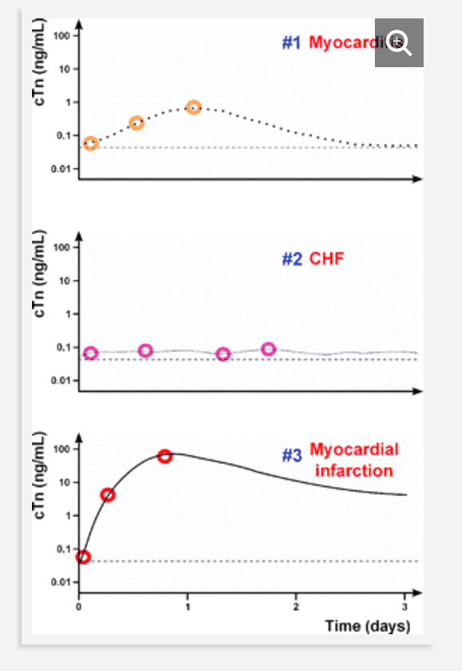

STEP 2 — 帶走一張圖就夠了：cTn 動態曲線區分心肌損傷、CHF、AMI。

重點不是查得到，是查完之後留下什麼。一次查詢 → 一張圖 → 一句寫進病歷的 assessment。

19

FREE RESOURCES

04 / 花很少的錢，一直學下去

## Continued learning with limited costs…

[figure not shown]

ECG Wave-Maven — Harvard/BIDMC 的免費心電圖自我評量題庫，可 quiz mode 或 reference mode。

20

EVIDENCE

04 / 讀過 ≠ 記住 2026 增修

## 把「讀過的」變成「叫得出來的」

- **測驗效應（testing effect）：**隨機對照試驗顯示， 「反覆測驗」在 6 個月後的長期記憶顯著優於「反覆閱讀」<sup>8</sup>。 重讀筆記是效率最差的複習方式之一。
- **間隔複習（spaced repetition）：**把測驗分散在時間軸上， 效果比集中複習更好，且此結論在醫學教育的系統性回顧／統合分析中持續被支持<sup>9,10</sup>。
- **住院醫師版做法：**看完一個病人 → 當天寫 3 個自問題（不是筆記）→ 第 1 天、第 7 天、第 30 天各回答一次。用 Anki 或紙卡都可以。

6 mo

RCT 追蹤區間：重複測驗組長期保留率顯著較高<sup>8</sup>

1·7·30

最省力的間隔複習節奏（天）

21

EVIDENCE

04 / 為什麼「做很多」不等於「變很強」 2026 增修

## Deliberate Practice 的四個必要條件<sup>11</sup>

01

### 明確且吃力的目標

針對**特定弱項**設計任務，而不是重複你已經會的部分。舒服＝沒在練。

02

### 即時的專家回饋

做完當下就要知道對不對。沒有回饋的重複，只會把錯誤練得更熟。

03

### 反覆的機會

同一個動作要有機會做第二次、第三次──這是模擬訓練存在的理由。

04

### 時間與解題空間

要有停下來思考「為什麼錯」的餘裕，不能全部塞在值班縫隙裡。

殘酷的推論：值了 300 個班，如果沒有回饋與回看，第 300 個班的你和第 30 個班的你差距有限。 **年資會自己長，能力不會。**

22

HOW-TO

04 / 一個立刻能用的工具 2026 增修

## SNAPPS：把 case presentation 變成學習事件<sup>12</sup>

步驟

你在查房時要說的那句話

S — Summarize

「這個病人簡短來說是……」（不超過 1 分鐘）

N — Narrow

「我覺得可能是 A 或 B。」（把鑑別診斷縮到 2–3 個）

A — Analyze

「A 比 B 可能，因為……」（比較，而不是列清單）

P — Probe

「我不確定的是……可以請教嗎？」（主動問，這步最關鍵）

P — Plan

「所以我打算……」（提出自己的計劃，不要等指令）

S — Select

「我今天要回去查的問題是……」（自選一個學習議題）

隨機對照試驗的統合分析支持 SNAPPS 能改善臨床推理表現<sup>12</sup>。最大的價值在第 4 步：把「不懂」講出來。

23

05

HANDS & EYES

## 超音波與理學檢查

Combined ultrasound skills and rational physical exam.

24

POCUS

05 / 從摸得到探頭，到敢下判斷 2026 增修

## POCUS 的分級學習路徑

LEVEL 1 · R1

### 看得到

認識機器與探頭、取得標準切面、辨識正常解剖。目標：**IVC、胸腔積液、膀胱、心包積液**。

LEVEL 2 · R2

### 看得懂

把影像連到臨床決策：容積狀態、B-lines、LV 收縮力目測、DVT 兩點壓迫。**要有人回看你的影像。**

LEVEL 3 · R3+

### 做得穩

導引式操作（胸水、腹水、中央靜脈、腰椎穿刺）＋ 教學能力。

- SHM 的立場聲明明確指出：**POCUS 的訓練與評量架構仍不足**， 並就 applications／training／assessments／program management 四個面向提出指引<sup>13</sup>。
- 2026 年的敘述性回顧比較家醫、急診、內科三個專科的 POCUS 課程指引， 共同結論是：「有結構的課程 ＋ 影像品質回饋」是關鍵，時數本身不是<sup>14</sup>。

25

POCUS

05 / 為什麼要「combined」

## 超音波不是取代理學檢查， 是給理學檢查即時回饋

床邊做完這個

立刻用超音波驗證

頸靜脈怒張評估 JVP

掃 IVC 直徑與呼吸變異 → 你的手感對不對？

聽到雙側下肺囉音

掃肺 B-lines → 是肺水腫還是肺纖維化？

觸診心尖搏動位置

Parasternal long axis → LV 有沒有真的擴大？

叩診發現濁音界線

掃胸腔積液 → 量有多少、穿得穿不得？

這就是**刻意練習的四個條件**在床邊的落地版：明確任務、即時回饋、大量重複、當場檢討。 超音波是全內科最容易取得「即時回饋」的技能。

26

06

WRITING & RESEARCH

## 寫作與研究

Knowledge, analysis, and writing — 三件事其實是同一件事。

27

WRITING

06 / To improve writing skills

## 先讀 *The Elements of Style*<sup>15</sup>

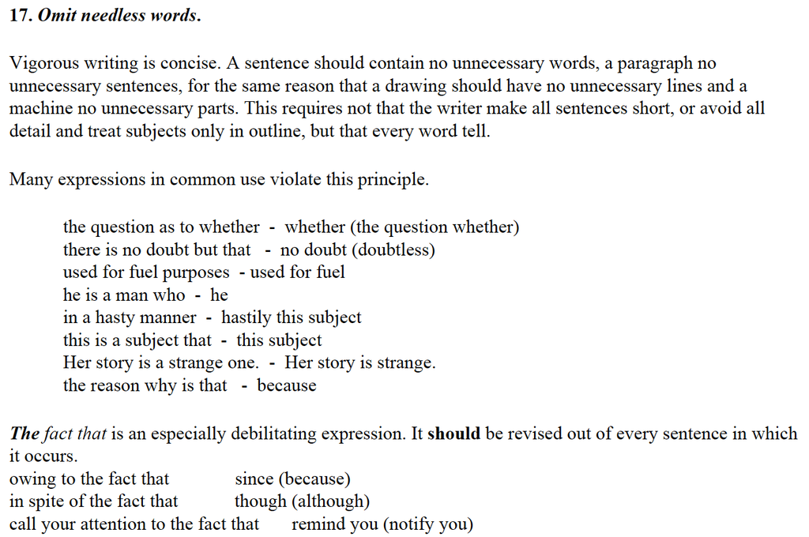

Rule 17 — Omit needless words.

Vigorous writing is concise.

「一個句子不該有多餘的字，一個段落不該有多餘的句子； 正如一張圖不該有多餘的線條，一部機器不該有多餘的零件。」

這不是文學要求，是醫學要求。病歷、會診單、家屬解釋、論文 abstract──全部同一個原則。

28

WRITING

06 / 怎麼練 2026 增修

## 寫作也可以刻意練習

日常

### 病歷就是練習場

每天挑一份 A/P，逼自己把 5 行縮成 3 行且不流失資訊。這是最高頻的寫作訓練，而且免費。

每週

### Reverse outline

拿一篇你讀懂的 paper，把每段用一句話寫出來。你會發現好文章的骨架非常簡單。

每季

### 寫完一份完整草稿

Case report 或 letter 都好。**寫完**比**寫好**重要──沒有完成過的人無法改進。

- **IMRaD 的順序不是寫作順序：**先寫 Methods → Results → 圖表 → Discussion → Introduction → Abstract → Title。
- **刪掉這些詞：**the fact that、in order to、it should be noted that、由於……的緣故。中英文都適用。
- **找一個會改你稿的人。**沒有回饋的寫作＝沒有回饋的重複＝把錯誤練熟。

29

RESEARCH

06 / Research issue

## 研究這件事，先把三件工具搞定

DATA

### Collecting data

**REDCap**（research electronic data capture）──跨機構通用、有稽核軌跡、符合研究規範<sup>16,17</sup>。不要再用 Excel 收案。

STATS

### Medical statistics

**R** 或 **SPSS**。R 免費、可重現、社群大；SPSS 上手快。二選一，然後把它練熟。

REF

### Reference manager

原講：**EndNote**。2026 更新：授權與跨平台考量下，Zotero 已是更務實的選擇。

三個工具的共同點：都是一次投資、終身受用。R1 花兩個週末學會，往後十年每一篇論文都在回收。

30

TOOLCHAIN

06 / 工具鏈 2026 2026 增修

## 從收案到投稿的完整工具鏈

階段

工具與要點

收案 / 資料

REDCap（表單設計、資料字典、稽核軌跡）<sup>16,17</sup>；去識別化流程要在 IRB 前就定案

分析

R（tidyverse / gtsummary）或 Python；**把分析寫成 script，不要用滑鼠點**──才能重現

文獻管理

Zotero ＋ 瀏覽器外掛；PDF 全文可全文檢索；共享資料庫給研究團隊

寫作

版本控制（雲端硬碟版本紀錄或 Git）；圖表用 vector 格式輸出

AI 輔助

可用於：語法潤飾、程式碼除錯、文獻整理骨架。不可用於：代寫結論、生成參考文獻

31

EVIDENCE

06 / 2023 那份簡報還沒有這一頁 2026 增修

## 住院醫師使用 AI 的三條界線

GREEN

### 可以放心用

英文潤飾、把長文獻整理成表、程式碼除錯、自我測驗出題、把病歷摘要成教學案例（**去識別化後**）。

AMBER

### 用了要查證

臨床問題的初步解答、鑑別診斷腦力激盪、藥物交互作用。**一律回去對 guideline 或原始文獻。**

RED

### 不要做

把可識別的病人資料貼進去；讓 AI 產生參考文獻；用 AI 代替自己形成臨床判斷。

- 系統性範疇回顧的核心建議：**學習者需要被特別訓練「評估 AI 產出的正確性」**， 機構則需建立問責、倫理與隱私的規範<sup>18</sup>。
- 最需要警覺的是 **cognitive offloading（認知外包）與 automation bias**── 當 AI 幫你想，你就沒有在練臨床推理；這在團隊決策情境中已被觀察到<sup>19</sup>。

32

07

COMMUNICATION

## 溝通：一張紙，一枝筆

33

COMMUNICATION

07 / 核心能力 ⑥

## Counseling with patients or families

- **一張紙，一枝筆，說明清楚。**
- **畫圖說明的能力很重要……**  
  心臟解剖、狹窄的位置、支架放在哪裡、接下來三天會發生什麼──畫出來，家屬才真的懂。
- **「說明」不是只有「說」才算數。**  
  說完之後請對方複述一次，你才知道他懂了沒有。

[figure not shown]

多部田憲彥《1枝筆＋1張紙，說服各種人》──圖解溝通術，非醫學書，但每一頁都能用在家族會議上。

34

EVIDENCE

07 / 這不是個人偏好，是有證據的 2026 增修

## 圖像為什麼真的比較有效<sup>20</sup>

- 跨健康教育、心理學、教育學與行銷領域的回顧指出： 圖像若與文字／口說內容緊密連結，可顯著提高注意力與回憶率<sup>20</sup>。
- 對**健康識能較低**的病人與家屬，圖像帶來的理解與遵囑改善幅度最大<sup>20</sup>。
- 實務組合：**畫圖 ＋ 口頭說明 ＋ teach-back（請對方複述）**，三者一起用效果最好。

SPIKES

### 壞消息告知六步驟

**S**etting 環境 · **P**erception 先問對方知道多少  
**I**nvitation 詢問想知道多少 · **K**nowledge 給資訊  
**E**motion 回應情緒 · **S**trategy 談下一步  
把你的那張圖，放在 K 這一步。

35

08

TIME MANAGEMENT

## 醫師的時間管理

整場演講最實用的一段。因為前面所有計劃，都要有時間才能執行。

36

EVIDENCE

08 / 先面對現實 2026 增修

## 你的時間去哪了

27.0%

門診時段中  
**真正面對病人**的時間<sup>21</sup>

49.2%

花在**電子病歷與桌面work**的時間<sup>21</sup>

1 : 2

每 1 小時直接照護  
≈ **2 小時**文書作業<sup>21</sup>

430 hr

該時間動作研究的  
實地觀察總時數<sup>21</sup>

這是四個專科（家醫、內科、心臟、骨科）共 57 位醫師的直接觀察結果<sup>21</sup>。 意思是：你不可能「擠出」時間，你只能「設計」時間。 所以下面三頁講的是系統，不是意志力。

37

TOOLS

08 / 工具 ①②

## Gmail：兩個被低估的功能

按鍵 b

### 「延後到…」Snooze

這個功能可以設定做為**提醒自己的 timer**。  
可以長達很多週！甚至隔年！  
用法：現在處理不了的事 → 按 b → 指定它未來自己跳回收件匣。

Tasks

### 把信變成待辦

可以利用 **Tasks**、設到期日，或是作專案管理。  
一封信 →「加入工作」→ 收件匣清空，但事情沒有掉。

核心邏輯：收件匣是「別人的待辦清單」，不是你的。 所有進來的東西都要在 60 秒內決定：**做掉 / 排程 / 委派 / 刪除**。

38

TOOLS

08 / 工具 ③ ＋ 實際作為

## Time and Task Management

OMNIFOCUS

### For Mac and iPhone users

行程、專案、待辦事項管理。  
2026 補充：Things 3、Todoist、Apple 提醒事項＋捷徑，或 Notion／Obsidian 都可以。 **工具不重要，「有一個唯一的收集箱」才重要。**

- **每天把 e-mail 清空。**
- **在記住與忘掉作取捨：**  
  讓 system 記住，讓自己當下忘掉，之後有空時再回顧並有時間專注。
- **找時間運動與陪家人。**  
  這一條寫在時間管理裡，不是寫在「行有餘力」裡。

39

09

RESILIENCE & CAREER

## 自我保護、心理調適 與生涯選擇

能持續，才有進步。這是整份計劃的地基。

40

EVIDENCE

09 / 如何保持愉快心情 2026 增修

## 先承認這是系統問題，不是你不夠堅強

- 全國性研究顯示：**工時與住院醫師的壓力、耗竭程度呈現明確關聯**； 高耗竭專科的族群差異也已被量化<sup>22,23</sup>。
- 日本全國調查發現：patient care ownership（對病人的責任感）與較低耗竭、較高工作滿意度相關<sup>24</sup>── 有意義感是保護因子，而不是負擔。
- 兩家醫院的隨機對照試驗顯示：**簡短的正念介入**即可改善臨床人員的正念行為與身心健康<sup>25</sup>。 不需要去閉關，短的就有效。

可執行的四件事

### 寫進你的計劃裡

**①** 每週固定運動時段，當成值班一樣排。  
**②** 每天離院前 5 分鐘，寫下一件今天做對的事。  
**③** 找到至少一位可以講真話的同儕。  
**④** 出現持續失眠、去人格化、對病人失去興趣 → 主動求助，這是症狀不是缺點。

41

CAREER

09 / Career

## 三條路，沒有標準答案

01

### Medical center

教學、研究、次專科深度、複雜病人。  
代價：升等壓力、行政負擔、時間破碎。  
需要的計劃：研究與發表的長線佈局。

02

### Regional or local hospital

臨床廣度、自主性高、與社區連結深。  
代價：資源與人力較少、需要更全能。  
需要的計劃：跨領域的臨床技能與 POCUS。

03

### Clinics

時間可控、經營自主、長期照護關係。  
代價：經營風險、學術連結變弱。  
需要的計劃：經營管理與持續進修的自律機制。

回到第一頁：Nobody is the same. 三條路需要的能力組合不同，所以**你的自我進修計劃，要往你選的那條路傾斜**── 但六大核心能力的底線，三條路都一樣。

42

TAKE THIS HOME

10 / 離開這個房間之後 2026 增修

## 90 天啟動清單

時間

做這件事

今天

打開行事曆，把「期中檢討」「期末檢討」兩個日期設成重複事件。

本週

用一頁式模板寫下 3 個目標，每個都有數字與截止日。拿給一位學長看。

第 2 週

建立自己的「好來源清單」：5 個期刊、3 個免費學習網站、1 個文獻管理軟體。

第 1 個月

Gmail 收件匣清空一次，設定 snooze 與 Tasks 的固定流程。開始 1·7·30 自我測驗。

第 2 個月

找到 POCUS 的回看機制（誰幫你看影像）。完成第一份 reverse outline。

第 3 個月

回看第一份計劃：哪些做到、哪些沒有、為什麼。**改寫，然後繼續。**

43

10 / 最後

# 計劃的價值不在於 被完成， 而在於被回顧

2023 年那份簡報只有三句話：comprehensive、goal-focused、step-by-step。  
三年後回頭看，會發現真正困難的從來不是「訂計劃」，而是**三個月後還願意打開它**。

謝慕揚 · 新竹臺大分院 心臟內科 · 2023-04-28 原講 ／ 2026 增修

44

REFERENCES

REFERENCES 1 / 2

## 參考文獻

- **1**Davis DA, Mazmanian PE, Fordis M, Van Harrison R, Thorpe KE, Perrier L. Accuracy of physician self-assessment compared with observed measures of competence: a systematic review. *JAMA.* 2006;296(9):1094-1102.
- **2**Li ST, Paterniti DA, Co JPT, West DC. Factors associated with successful self-directed learning using individualized learning plans during pediatric residency. *Acad Pediatr.* 2010;10(2):124-130.
- **3**Accreditation Council for Graduate Medical Education. Internal Medicine Milestones 2.0 (2021)；The Milestones Guidebook for Residents and Fellows. ACGME.
- **4**Sawatsky AP, Halvorsen AJ, Daniels PR, et al. Characteristics and quality of rotation-specific resident learning goals: a prospective study. *Med Educ Online.* 2020;25(1):1714198.
- **5**Sandars J, Cleary TJ. Self-regulation theory: applications to medical education. AMEE Guide No. 58. *Med Teach.* 2011;33(11):875-886.
- **6**Free open access medical education (FOAM): quality indicators and critical appraisal techniques for quality assessment and content discovery. 2024.
- **7**Guckian J, et al. Social media quality in undergraduate medical education: a reconceptualisation and taxonomy. *Clin Teach.* 2025.
- **8**Larsen DP, Butler AC, Roediger HL. Repeated testing improves long-term retention relative to repeated study: a randomised controlled trial. *Med Educ.* 2009;43(12):1174-1181.
- **9**Larsen DP, Butler AC, Roediger HL. Test-enhanced learning in medical education. *Med Educ.* 2008;42(10):959-966.
- **10**Maye H, et al. The effectiveness of spaced repetition in medical education: a systematic review and meta-analysis. *Clin Teach.* 2026.
- **11**Ericsson KA. Deliberate practice and the acquisition and maintenance of expert performance in medicine and related domains. *Acad Med.* 2004;79(10 Suppl):S70-S81.
- **12**Flores-Cohaila JA, Vizcarra-Jiménez SF, Bermúdez-Peláez MF, et al. Effects of SNAPPS in clinical reasoning teaching: a systematic review with meta-analysis of randomized controlled trials. *Diagnosis (Berl).* 2024;11(3).

45

REFERENCES

REFERENCES 2 / 2

## 參考文獻（續）

- **13**Soni NJ, Schnobrich D, Mathews BK, et al. Point-of-care ultrasound for hospitalists: a position statement of the Society of Hospital Medicine. *J Hosp Med.* 2019;14:E1-E6.
- **14**Nickols J, Douthit N. Point-of-care ultrasound guidelines from family medicine, emergency medicine, and internal medicine for curriculum development: a narrative review. *J Grad Med Educ.* 2026;18(3).
- **15**Strunk W Jr, White EB. *The Elements of Style.* 4th ed. Boston: Allyn & Bacon; 2000.（Rule 17: Omit needless words）
- **16**Harris PA, Taylor R, Thielke R, Payne J, Gonzalez N, Conde JG. Research electronic data capture (REDCap). *J Biomed Inform.* 2009;42(2):377-381.
- **17**Harris PA, Taylor R, Minor BL, et al; REDCap Consortium. The REDCap consortium: building an international community of software platform partners. *J Biomed Inform.* 2019;95:103208.
- **18**Xu X, Chen Y, Miao J. Opportunities, challenges, and future directions of large language models, including ChatGPT in medical education: a systematic scoping review. *J Educ Eval Health Prof.* 2024;21:6.
- **19**Khan M, Edgcomb J, Heldt J, et al. Artificial intelligence in psychiatric graduate medical education. *Acad Psychiatry.* 2026.
- **20**Houts PS, Doak CC, Doak LG, Loscalzo MJ. The role of pictures in improving health communication: a review of research on attention, comprehension, recall, and adherence. *Patient Educ Couns.* 2006;61(2):173-190.
- **21**Sinsky C, Colligan L, Li L, et al. Allocation of physician time in ambulatory practice: a time and motion study in 4 specialties. *Ann Intern Med.* 2016;165(11):753-760.
- **22**Tan SF, Siddiqui H, Pinto A, et al. Work hours, stress, and burnout among resident physicians. *JAMA Netw Open.* 2026;9(1). doi:10.1001/jamanetworkopen.2025.53974
- **23**Tan SF, Siddiqui H, Paur B, et al. Demographics in distress: a national study of burnout and well-being of resident physicians in high-burnout specialties. *BMC Med Educ.* 2026;26.
- **24**Fujikawa H, Tamune H, Nishizaki Y, et al. Associations between patient care ownership, burnout, and job satisfaction among medical residents: a nationwide cross-sectional study in Japan. *Sci Rep.* 2026.
- **25**Greene MT, Houchens N, Sheffield V, et al. Brief mindfulness-based intervention to improve clinician mindful behaviours and well-being at two US hospitals: a randomised controlled, mixed methods trial. *BMJ Qual Saf.* 2026.
- **26**多部田憲彥（周若珍 譯）。《1枝筆＋1張紙，說服各種人：最強圖解溝通術》。核果文化；2014。

46